# A2 - Complete Community Assessment of Marin City and Marin County

Bella Raja

1/26/2022

[interactive chart not shown]

This map shows the distributions of various amenities I chose for my complete communities scoring and assessment.

[interactive chart not shown]

Marin City small unincorporated area of Marin County surrounded by the more affluent Sausalito and Mill Valley. It is often cited as a large site of inequities especially when it comes to health care and healthy food access compared to the rest of Marin County.

Baseline score

```
## [1] 9.965881
```

This baseline score takes into account the amenity ranks, value, and decay to calculate a baseline community score to be compared with the final Marin City community score.

```
## # A tibble: 4 × 3
## # Groups:   id [2]
##      id mode    score
##   <int> <chr>   <dbl>
## 1     1 driving 1.59
## 2     1 walking 0.151
## 3     2 driving 1.59
## 4     2 walking 0.144
```

### Map of Marin City Complete Communities Analysis

[interactive chart not shown]

The census block group (cbg) closest to the highway has a lower score that the other larger block group. It’s also important to note that Marin City Eastern portion sits right on the Redwood Highway putting it very close to major sources of pollution. It would be interesting to follow-up this analysis using CalEnviroScreen or creating a complete community score when it comes to climate change in the future.

Interestingly, there were not any greengrocers or atms listed in Marin City cbgs. This also speaks to the equity and access issue to healthy food options and accessible cash. The closest hospital listed, “Marin General Hospital” is 15 minutes by driving.

Changes in land use could be to promote more equity in access to healthy food, health care, and financial services near by. Although Marin City is a smaller-unincorporated region of Marin County, the stark and concentrated disparities need to be addressed to promote county-wide equity.

### Assessing Broader Health Access Disparities in Marin County

```
## replacing null geometries with empty geometries
## Simple feature collection with 43545 features and 50 fields (with 7 geometries empty)
## Geometry type: POINT
## Dimension:     XY
## Bounding box:  xmin: -176.6576 ymin: -14.32821 xmax: 145.7242 ymax: 71.29834
## Geodetic CRS:  WGS 84
```

[interactive chart not shown]

```
## 0.7609807 [1]
```

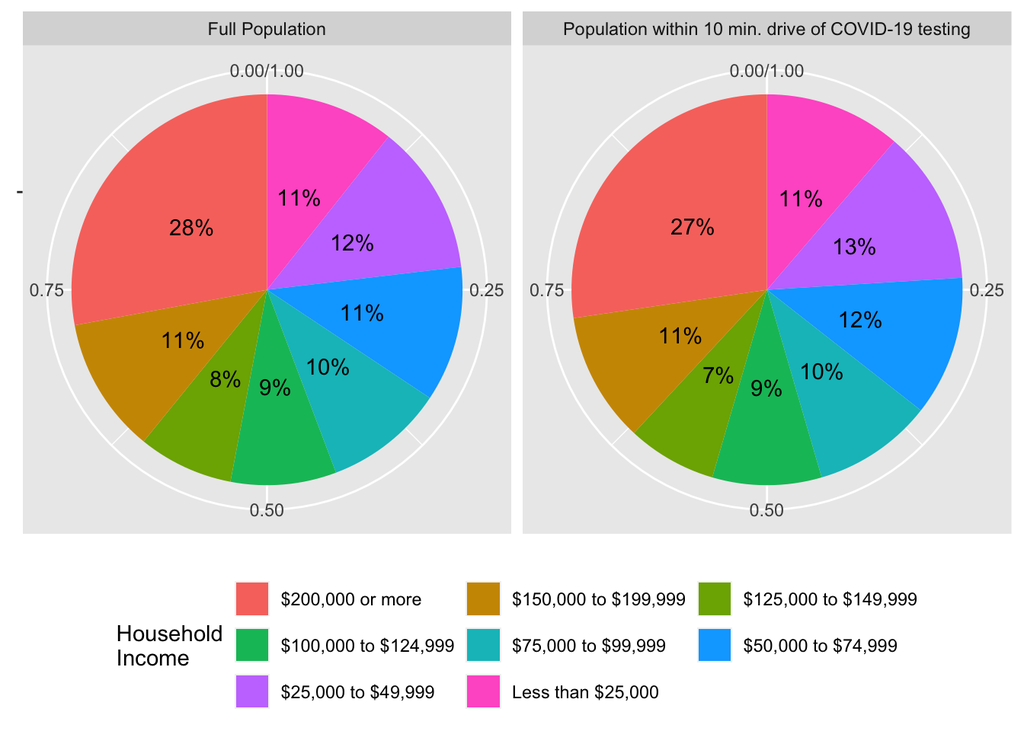

It is fascinating how closely the Marin County income tiers correspond with breakdowns of access to close COVID-19 testing. Despite the median annual household income in Marin County being around $115,246, the median annual household income in Marin City is about $45,841. These disparities are reflected in lacking access to amenities such as greengrocers, atms, and more than one hospital within 15 minutes driving distance. Additionally, Marin City is predominately composed of African American and Latinx communities in contrast with its neighboring cities such as Sausalito and Mill Valley and more broadly the rest of Marin County which is predominately white.

If Marin City residents need to drive 15 minutes or more to receive healthcare, access healthy food, or deposit /draw cash that sets a disproportionate burden on a community that is already predominately low-income and historically discriminated against. Future land use should take into account these omissions and needs of the community and collaborate with community leaders to find the best locations and amenities to fit the needs of the community.